# FinalProject

December 19, 2018

## Introduction to Project

- Goal is to correctly predict ratings when looking at ratings as > 4.2 stars and <= 4.2 stars
- As such, ratings will need to be transformed into a dummy variable instead of numeric
- Data was pulled from Kaggle and was called Google Play Store Apps
- Was scraped directly from the google play store originally

## The Dataset

- Number of apps = 10841
- Dependant variable = Rating - coverted to > 4.2 and <= 4.2
- Numerical variables: Reviews, Price, Size, and Last Updated
- Categorical variables: Category, Type, Content Rating, and Genre.
- Discarded variables: Current Version, Andriod Version, Genres(later on), and App

## Cleaning

- Pretty easy, converting columns primarily
- One exception was size.

```r
df$Size = as.character(df$Size)
df$Size = gsub("k", "000", df$Size)
df$Size = gsub("M", "", df$Size)
df$Size = as.numeric(df$Size)
df$Size = ifelse(df$Size < 1000, df$Size*1000000,df$Size)
```

## Some Graphs

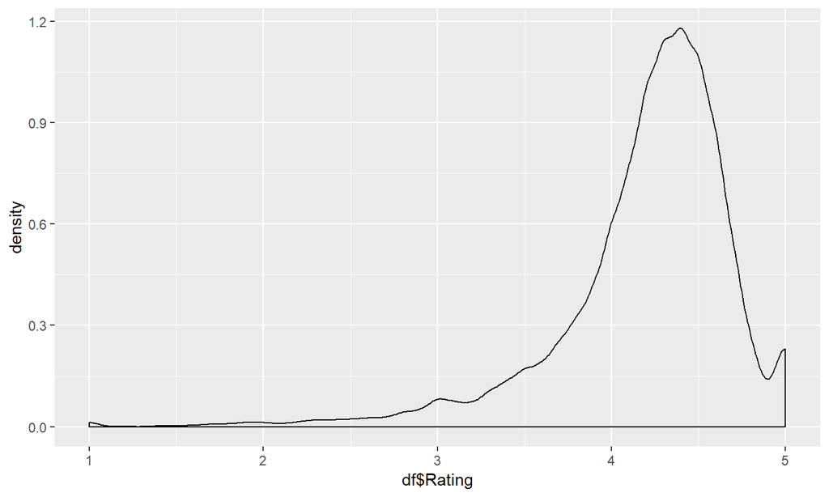

## Continued

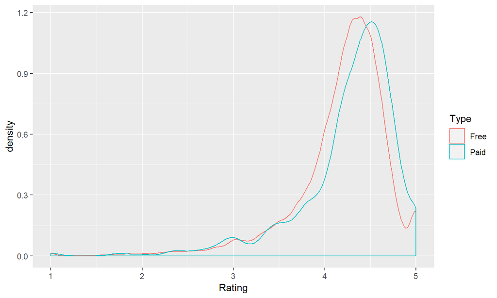

## Final graph

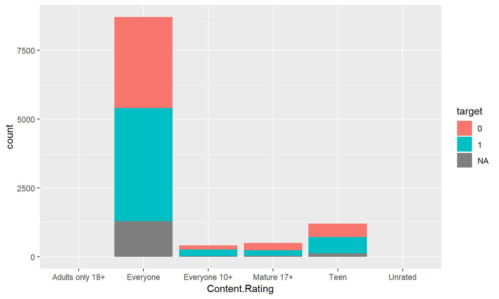

## Missing values, recoding, and encoding

- The three methods used were: removing incomplete cases, replacing missing values with mean or mode, and replacing with knn imputation or mode
- Recoding was done on categories (33 levels) and installs(21 levels), Genres was deleted (120 levels)
- Encoding methods used were dummy variables and numeric substitution

## Modeling

- Chosen models were Bayesian Generalized Linear model and rpart along with the required two
- Ran one entire dataset on a wide range of parameters, took the best parameters, and used those for all other datasets
- Took 30 minutes to run ranger once with the range of parameters, hence this approach

## Overall Best Model

- random forest - mtry = 8, splitrule = gini, min.node.size = 2
- dataset was knn imputed, recoded, and dummy variable encoded.
- accuracy was .727399
- despite this, every other model worked best on a dataset that was mean/mode replaced and nothing else
- encoding by simply replacing categorical with numerics almost always lowered accuracy
- Other models best accuracy were all around .67